# CSCI 385 - Third Deliverable

Brandon Weaver

12/7/2020

# Video Games Sales Analysis Part 3

# Introduction

The primary goals of deliverable 3 are to improve upon the work done in deliverables 1 and 2. This will be done by loading in the data from RAWG.io using their API. Then I will join the two data sets so that I now have access to the `playtime` variable. Next I will continue conducting exploratory data analysis to see if the `playtime` variable is worth adding to the model. Finally, the plan is to create three different models. One with all of the data set that now factors in `playtime`, one where only low selling games are included, and lastly a model only including high selling games.

# Expansion of Data Set

```r
VGSales <- read_csv("Video_Games_Sales.csv")
baseurl <- "https://api.rawg.io/api/games?key=8fdd449e387c4197ad765b1222eafa73&page_size=40&dates=1980-01-01,2017-01-01"
pages <- list()
for(i in 1:100){
  mydata <- fromJSON(paste0(baseurl, "&page=", i))
  pages[[i+1]] <- mydata$results
}
RAWGData <- rbind_pages(pages)
```

The way that the second data set is collected is by calling Rawg.io’s API and then using the function rbind_pages to take the results and convert them from JSON data and turn it into a data frame.

```r
count(RAWGData)
```

```
##      n
## 1 4000
```

```r
RAWGDataShowcase <- RAWGData %>%
  select(-background_image, -ratings, -updated, -tags, -short_screenshots, -parent_platforms, -platforms, -genres)
head(RAWGDataShowcase)
```

```
##                         slug                        name playtime
## 1         grand-theft-auto-v          Grand Theft Auto V       69
## 2                   portal-2                    Portal 2       11
## 3    the-witcher-3-wild-hunt    The Witcher 3: Wild Hunt       51
## 4                tomb-raider          Tomb Raider (2013)       11
## 5 the-elder-scrolls-v-skyrim The Elder Scrolls V: Skyrim       44
## 6              left-4-dead-2               Left 4 Dead 2        9
##                                                                                                                                            stores
## 1     1, 3, 2, 7, 11, Steam, PlayStation Store, Xbox Store, Xbox 360 Store, Epic Games, steam, playstation-store, xbox-store, xbox360, epic-games
## 2                                 1, 3, 2, 7, Steam, PlayStation Store, Xbox Store, Xbox 360 Store, steam, playstation-store, xbox-store, xbox360
## 3                                                1, 3, 2, 5, Steam, PlayStation Store, Xbox Store, GOG, steam, playstation-store, xbox-store, gog
## 4 1, 3, 4, 7, 8, Steam, PlayStation Store, App Store, Xbox 360 Store, Google Play, steam, playstation-store, apple-appstore, xbox360, google-play
## 5                               1, 3, 6, 7, Steam, PlayStation Store, Nintendo Store, Xbox 360 Store, steam, playstation-store, nintendo, xbox360
## 6                                                                                                     1, 7, Steam, Xbox 360 Store, steam, xbox360
##     released   tba rating rating_top ratings_count reviews_text_count added
```

[output cut: 41 more lines]

The count of the second data set was included to cover a critique of deliverable 2 and to prove that their are 4000 unique games in the second data set. In order to better showcase the second data set several variable have been unselected because they included multiple values which print in an unclear way in R Markdown.

Some highlight variables that are not used for this deliverable but would be interesting to consider in future analysis is the `stores` variable that shows what stores each game was sold at, perhaps being available at more stores would equate to more sales.

Also included was an `added` variable that describes how many users of the website own the game. I have chosen not to include this variable in my models because they essentially measure the same thing as the `Global_Sales` variable in the first data set. In my opinion, it does not mean much to predict a variable by basing the predictions on the same variable in the other data set.

```r
RAWGDataPlaytime <- RAWGData %>%
  select(name, playtime)
```

Since `playtime` is the only variable from the second data set that is going to be used for the model. I made a select statement that only collects the `name` and the `playtime` of each game.

```r
finalData <- inner_join(VGSales,RAWGDataPlaytime,by=c("Name" = "name"))
count(finalData)
```

```
## # A tibble: 1 x 1
##       n
##   <int>
## 1  1908
```

This is the code that merges the two files through an inner join. An inner join was made instead of an outer join because including `playtime` would not be much use to the model unless every row had that variable included. Also this does bring up one limitation to the new models. This being that now the data set went from having over 16000 entries to only about 1900 entries. This also creates a new bias because of 4000 games that are included in the Rawg.io data set, they are the 4000 most popular games based on their meta critic score. This is important because it takes away representation from less popular games.

# Exploratory Data Analysis Continued

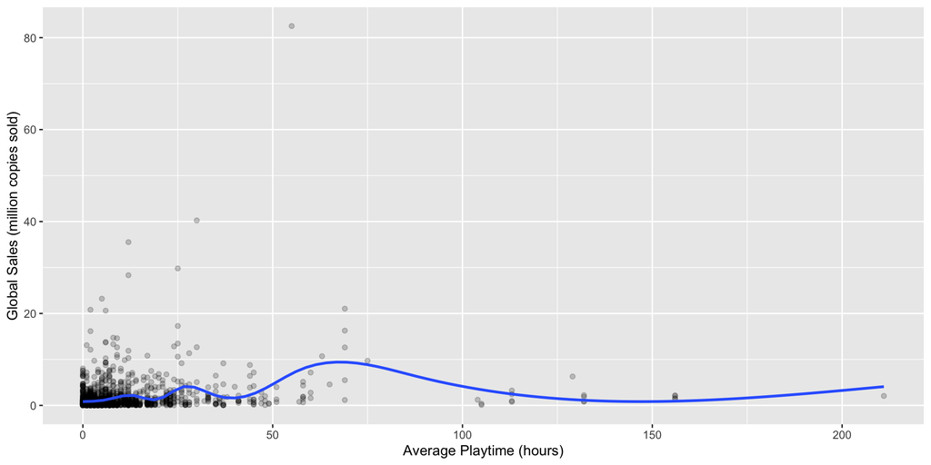

```r
ggplot(data = finalData, aes(x = playtime, y = Global_Sales)) + geom_point(alpha = 0.2) + geom_smooth(se=FALSE) +
  labs(x = "Average Playtime (hours)", y = "Global Sales (million copies sold)")
```

To continue with the data analysis, I have created a graph that compares the average `playtime` to the `Global_Sales` of each game. As you can see, while its not a linear correlation there does seem to be a “sweet-spot” where at about 25 to 30 hours of game play sales spike. Also, after about 50 hours there seems to be a sharp increase, however the number of games past 50 hours also start to decrease so this could be the case of outliers causing there to look like their is positive correlation. Given that their does seem to be some patterns and trends with `playtime` versus `Global_Sales`, I have chosen to move forward with my plan and integrate `playtime` into my final prediction model.

# Models Continued

For all four models that were made for this deliverable, the validation methodology has been fixed in order to address a fault in deliverable 2 and to meet best practice standards. Now the data set has been split 60/20/20 with 60% of the data being used to train the model, 20% to validate the model, and the last 20% to test the model at the very end. This is opposed to the previous deliverable where I simply had an 80/20 split with 80% to train the model and 20% to test the model. This new split is better because it helps to reduce bias and helps avoid the issue of over tuning towards the test set.

## full data set and playtime added

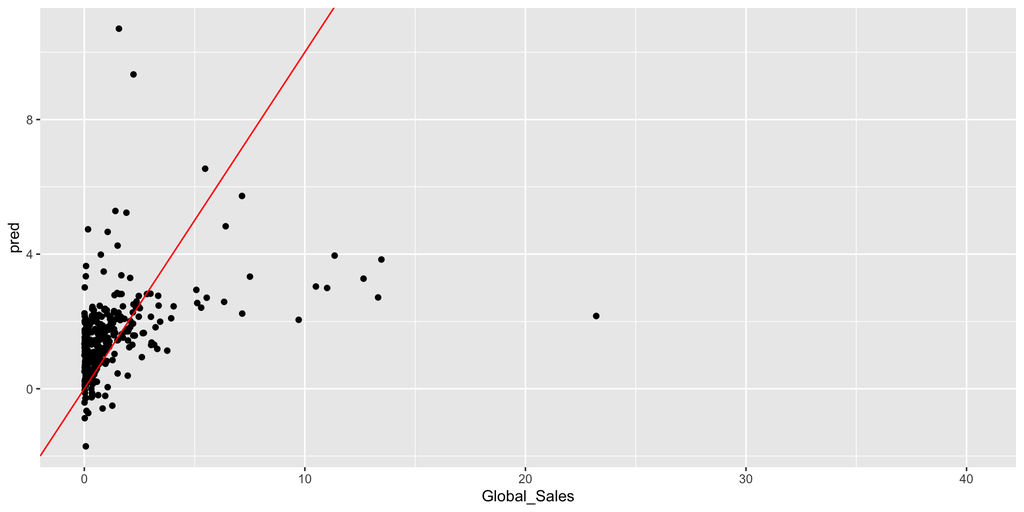

```r
rest_rows <- as.vector(createDataPartition(finalData$Global_Sales, p = 0.8, list = FALSE))
test <- finalData[-rest_rows, ]
rest <- finalData[rest_rows, ]

train_rows <- as.vector(createDataPartition(rest$Global_Sales, p = 0.75, list = FALSE))

train <- rest[train_rows, ]
validate <- rest[-train_rows, ]
VGmodel <- lm(Global_Sales ~ Critic_Score + User_Score + playtime, data = train)

predictions <- add_predictions(validate, VGmodel)

ggplot(data = predictions, mapping = aes(x = Global_Sales, y = pred)) +
  geom_point() +
  geom_abline(intercept = 0, slope = 1, color = "red")
```

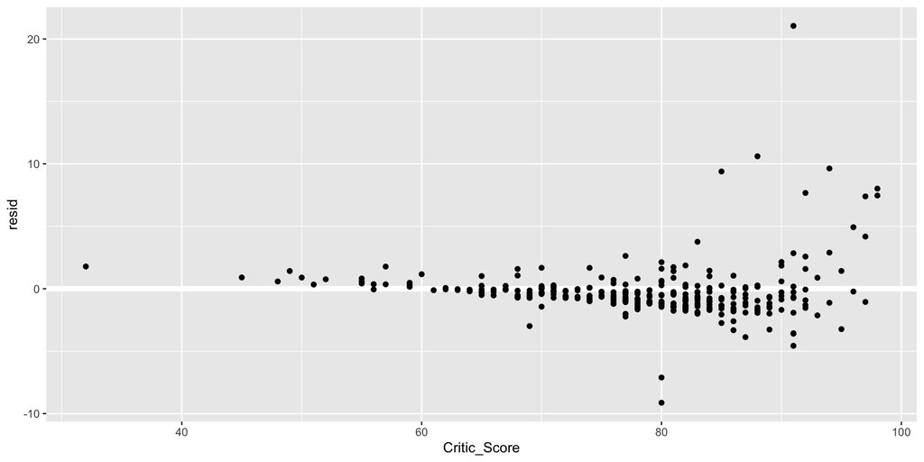

```r
resids <- add_residuals(validate, VGmodel)


ggplot(data = resids, mapping = aes(x = Critic_Score, y = resid)) +
  geom_ref_line(h = 0) +
  geom_point()
```

```r
clean <- predictions %>%
  filter(!is.na(pred))

summary(VGmodel)
```

```
##
## Call:
## lm(formula = Global_Sales ~ Critic_Score + User_Score + playtime,
##     data = train)
##
## Residuals:
##    Min     1Q Median     3Q    Max
## -8.043 -1.116 -0.500  0.335 78.390
##
## Coefficients:
##               Estimate Std. Error t value Pr(>|t|)
## (Intercept)  -3.888851   0.878595  -4.426 1.07e-05 ***
## Critic_Score  0.073533   0.013179   5.579 3.17e-08 ***
## User_Score   -0.109576   0.113387  -0.966    0.334
## playtime      0.060305   0.009347   6.452 1.78e-10 ***
## ---
## Signif. codes:  0 '***' 0.001 '**' 0.01 '*' 0.05 '.' 0.1 ' ' 1
##
## Residual standard error: 3.705 on 923 degrees of freedom
##   (220 observations deleted due to missingness)
## Multiple R-squared:  0.1029, Adjusted R-squared:    0.1
## F-statistic:  35.3 on 3 and 923 DF,  p-value: < 2.2e-16
```

```r
R2(clean$pred, clean$Global_Sales)
```

```
## [1] 0.1407405
```

```r
MAE(clean$pred, clean$Global_Sales)
```

```
## [1] 1.264981
```

```r
RMSE(clean$pred, clean$Global_Sales)
```

```
## [1] 2.276728
```

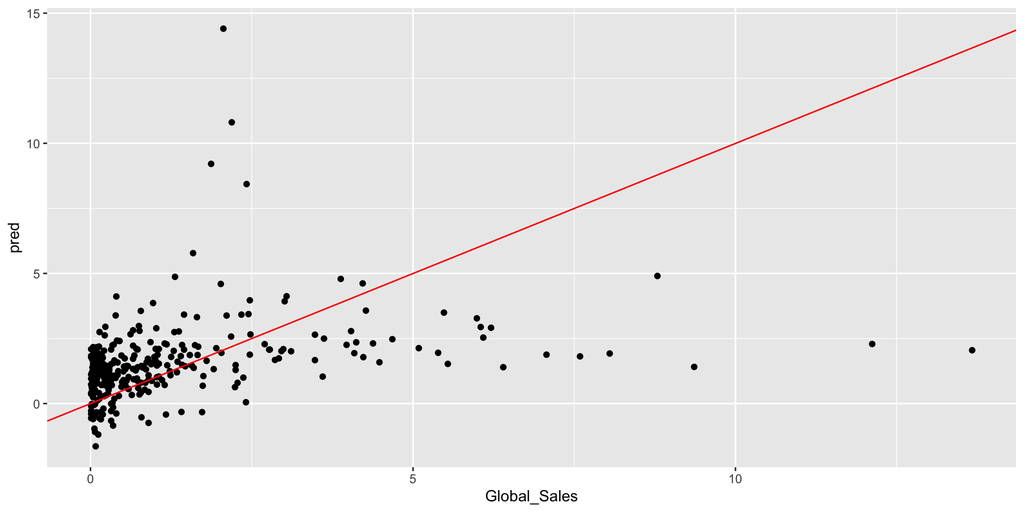

```r
predictions <- add_predictions(test, VGmodel)

ggplot(data = predictions, mapping = aes(x = Global_Sales, y = pred)) +
  geom_point() +
  geom_abline(intercept = 0, slope = 1, color = "red")
```

```r
clean <- predictions %>%
  filter(!is.na(pred))

R2(clean$pred, clean$Global_Sales)
```

```
## [1] 0.102448
```

```r
MAE(clean$pred, clean$Global_Sales)
```

```
## [1] 1.293927
```

```r
RMSE(clean$pred, clean$Global_Sales)
```

```
## [1] 2.016082
```

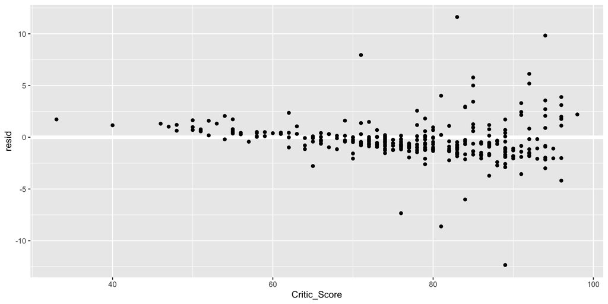

```r
resids <- add_residuals(test, VGmodel)

ggplot(data = resids, mapping = aes(x = Critic_Score, y = resid)) +
  geom_ref_line(h = 0) +
  geom_point()
```

## Low Sales With Playtime Added

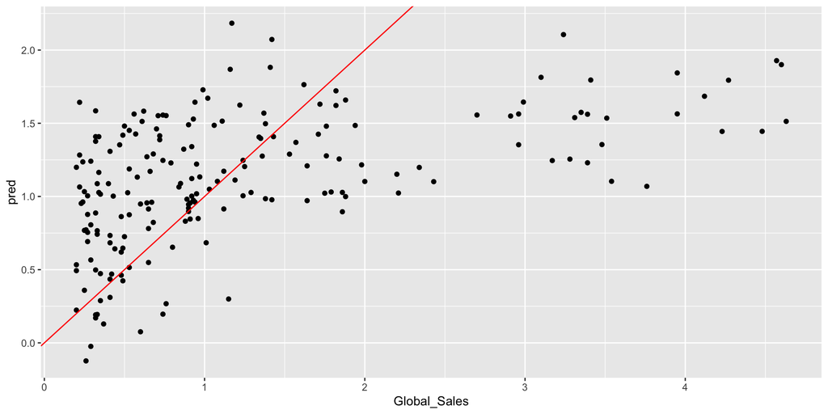

```r
lowSales <-  finalData %>%
  filter(Global_Sales <= 5) %>%
  filter(Global_Sales >= 0.2)


rest_rows <- as.vector(createDataPartition(lowSales$Global_Sales, p = 0.8, list = FALSE))
test <- lowSales[-rest_rows, ]
rest <- lowSales[rest_rows, ]

train_rows <- as.vector(createDataPartition(rest$Global_Sales, p = 0.75, list = FALSE))

train <- rest[train_rows, ]
validate <- rest[-train_rows, ]
VGmodel <- lm(Global_Sales ~ Critic_Score + User_Score + playtime, data = train)

predictions <- add_predictions(validate, VGmodel)

ggplot(data = predictions, mapping = aes(x = Global_Sales, y = pred)) +
  geom_point() +
  geom_abline(intercept = 0, slope = 1, color = "red")
```

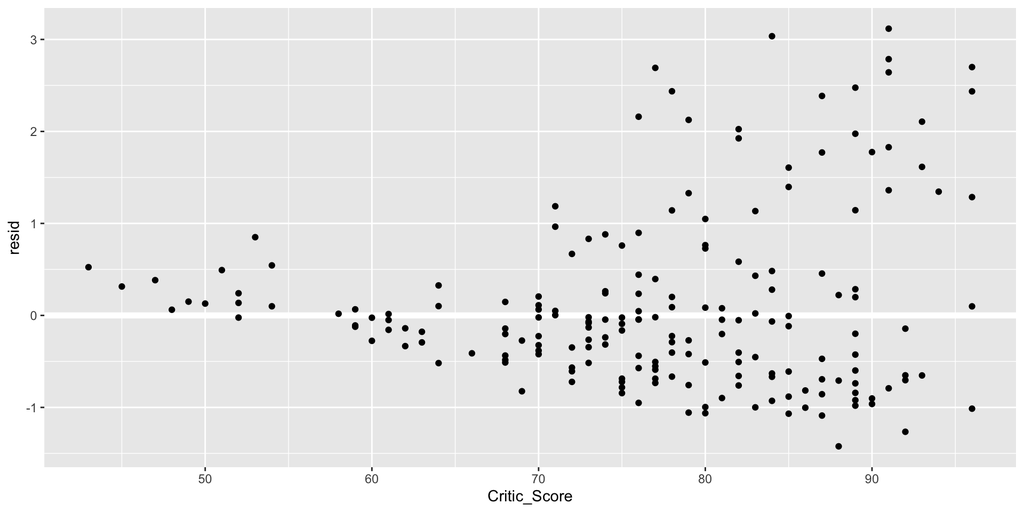

```r
resids <- add_residuals(validate, VGmodel)

ggplot(data = resids, mapping = aes(x = Critic_Score, y = resid)) +
  geom_ref_line(h = 0) +
  geom_point()
```

```r
clean <- predictions %>%
  filter(!is.na(pred))

summary(VGmodel)
```

```
##
## Call:
## lm(formula = Global_Sales ~ Critic_Score + User_Score + playtime,
##     data = train)
##
## Residuals:
##     Min      1Q  Median      3Q     Max
## -1.5459 -0.6086 -0.2188  0.4034  3.4383
##
## Coefficients:
##               Estimate Std. Error t value Pr(>|t|)
## (Intercept)  -1.342233   0.316854  -4.236 2.65e-05 ***
## Critic_Score  0.040673   0.004571   8.898  < 2e-16 ***
## User_Score   -0.098368   0.035958  -2.736  0.00642 **
## playtime      0.005775   0.002217   2.605  0.00943 **
## ---
## Signif. codes:  0 '***' 0.001 '**' 0.01 '*' 0.05 '.' 0.1 ' ' 1
##
## Residual standard error: 0.9058 on 579 degrees of freedom
##   (135 observations deleted due to missingness)
## Multiple R-squared:  0.1517, Adjusted R-squared:  0.1473
## F-statistic:  34.5 on 3 and 579 DF,  p-value: < 2.2e-16
```

```r
R2(clean$pred, clean$Global_Sales)
```

```
## [1] 0.2644887
```

```r
MAE(clean$pred, clean$Global_Sales)
```

```
## [1] 0.6826061
```

```r
RMSE(clean$pred, clean$Global_Sales)
```

```
## [1] 0.9566641
```

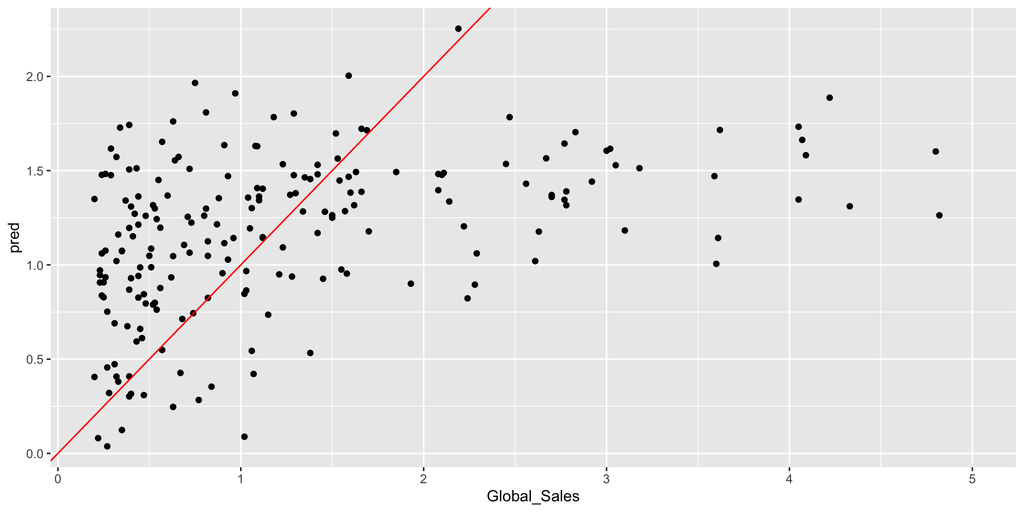

```r
predictions <- add_predictions(test, VGmodel)

ggplot(data = predictions, mapping = aes(x = Global_Sales, y = pred)) +
  geom_point() +
  geom_abline(intercept = 0, slope = 1, color = "red")
```

```r
clean <- predictions %>%
  filter(!is.na(pred))

R2(clean$pred, clean$Global_Sales)
```

```
## [1] 0.1724319
```

```r
MAE(clean$pred, clean$Global_Sales)
```

```
## [1] 0.6986264
```

```r
RMSE(clean$pred, clean$Global_Sales)
```

```
## [1] 0.9527722
```

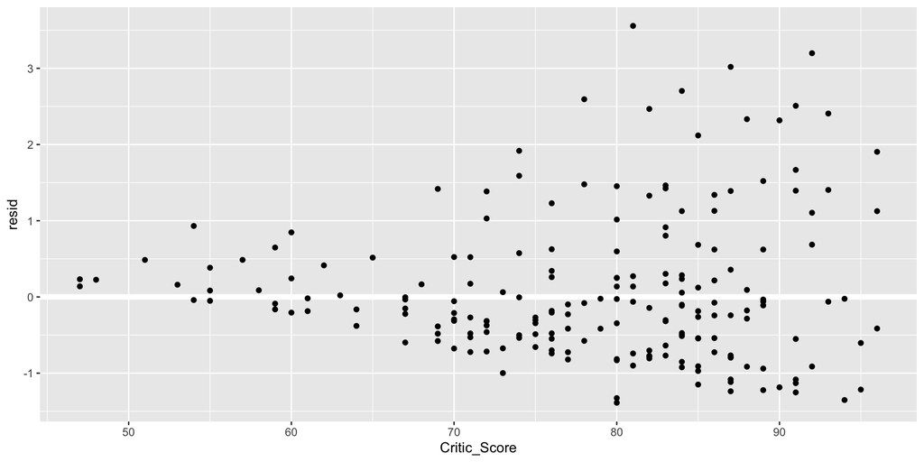

```r
resids <- add_residuals(test, VGmodel)

ggplot(data = resids, mapping = aes(x = Critic_Score, y = resid)) +
  geom_ref_line(h = 0) +
  geom_point()
```

The first conclusion to make is that the split of higher and lower selling games did increase the accuracy of the model. This is because the R^2 value is now .17 compared to the 0.10 that it was in the first model. Also, the mean average error went from 1.29 to 0.69. In addition, this model seems to have solved the issue that it was trying to address, which was that the original models were under valuing games that had a high critic score. Based on the residuals plot, there is now a randomness to it. This is important because it suggests that there are no longer any common trends that are dictating any inaccuracies in the model.

## High Sales With Playtime Added

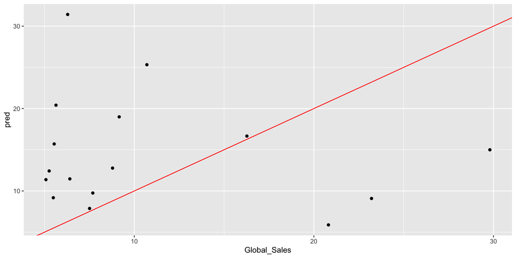

```r
highSales <-  finalData %>%
  filter(Global_Sales > 5)

rest_rows <- as.vector(createDataPartition(highSales$Global_Sales, p = 0.8, list = FALSE))
test <- highSales[-rest_rows, ]
rest <- highSales[rest_rows, ]

train_rows <- as.vector(createDataPartition(rest$Global_Sales, p = 0.75, list = FALSE))

train <- rest[train_rows, ]
validate <- rest[-train_rows, ]
VGmodel <- lm(Global_Sales ~ Critic_Score + User_Score + playtime, data = train)

predictions <- add_predictions(validate, VGmodel)

ggplot(data = predictions, mapping = aes(x = Global_Sales, y = pred)) +
  geom_point() +
  geom_abline(intercept = 0, slope = 1, color = "red")
```

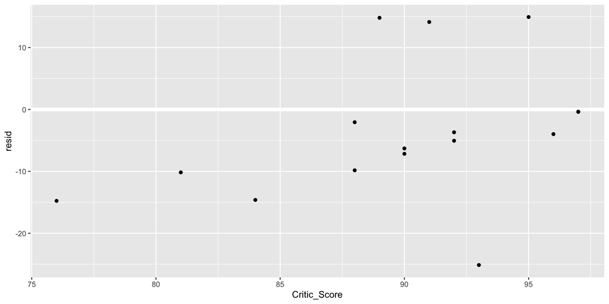

```r
resids <- add_residuals(validate, VGmodel)


ggplot(data = resids, mapping = aes(x = Critic_Score, y = resid)) +
  geom_ref_line(h = 0) +
  geom_point()
```

```r
clean <- predictions %>%
  filter(!is.na(pred))

summary(VGmodel)
```

```
##
## Call:
## lm(formula = Global_Sales ~ Critic_Score + User_Score + playtime,
##     data = train)
##
## Residuals:
##     Min      1Q  Median      3Q     Max
## -15.379  -5.545  -1.474   3.222  50.734
##
## Coefficients:
##              Estimate Std. Error t value Pr(>|t|)
## (Intercept)  67.19719   19.11878   3.515  0.00091 ***
## Critic_Score -0.87853    0.25965  -3.384  0.00135 **
## User_Score    2.41161    0.99993   2.412  0.01937 *
## playtime      0.21953    0.07252   3.027  0.00381 **
## ---
## Signif. codes:  0 '***' 0.001 '**' 0.01 '*' 0.05 '.' 0.1 ' ' 1
##
## Residual standard error: 9.964 on 53 degrees of freedom
##   (15 observations deleted due to missingness)
## Multiple R-squared:  0.245,  Adjusted R-squared:  0.2023
## F-statistic: 5.733 on 3 and 53 DF,  p-value: 0.001791
```

```r
R2(clean$pred, clean$Global_Sales)
```

```
## [1] 0.03452452
```

```r
MAE(clean$pred, clean$Global_Sales)
```

```
## [1] 9.210594
```

```r
RMSE(clean$pred, clean$Global_Sales)
```

```
## [1] 11.33345
```

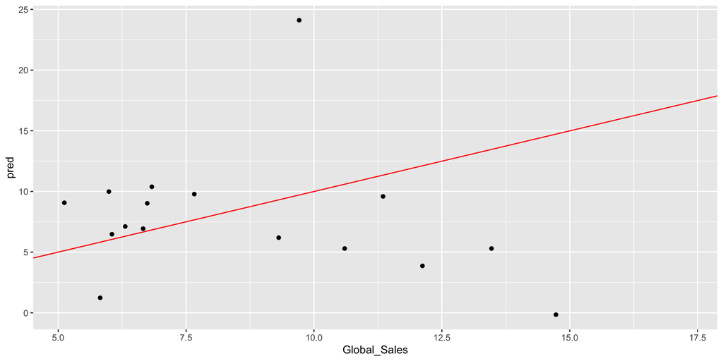

```r
predictions2 <- add_predictions(test, VGmodel)

ggplot(data = predictions2, mapping = aes(x = Global_Sales, y = pred)) +
  geom_point() +
  geom_abline(intercept = 0, slope = 1, color = "red")
```

```r
clean <- predictions2 %>%
  filter(!is.na(pred))

R2(clean$pred, clean$Global_Sales)
```

```
## [1] 0.04601556
```

```r
MAE(clean$pred, clean$Global_Sales)
```

```
## [1] 4.868129
```

```r
RMSE(clean$pred, clean$Global_Sales)
```

```
## [1] 6.523
```

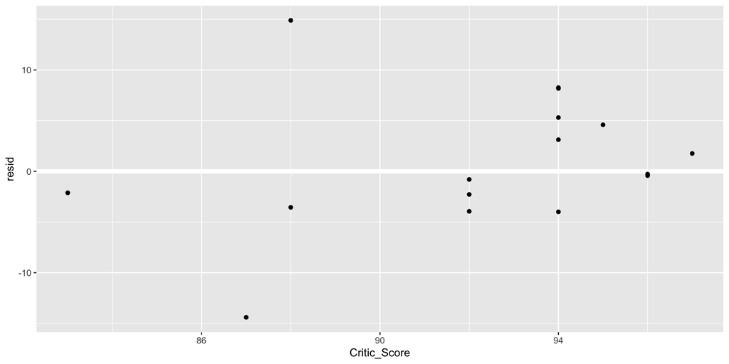

```r
resids2 <- add_residuals(test, VGmodel)

ggplot(data = resids2, mapping = aes(x = Critic_Score, y = resid)) +
  geom_ref_line(h = 0) +
  geom_point()
```

The main issue with this model derives from the lack of data points. This makes any predictions that it would make not mean much. Perhaps in the future, the data set could be split 50/50 and that could have the potential of fixing the issue. This is because it solve the problem where the top half has to few data points.

## full data set and no playtime added

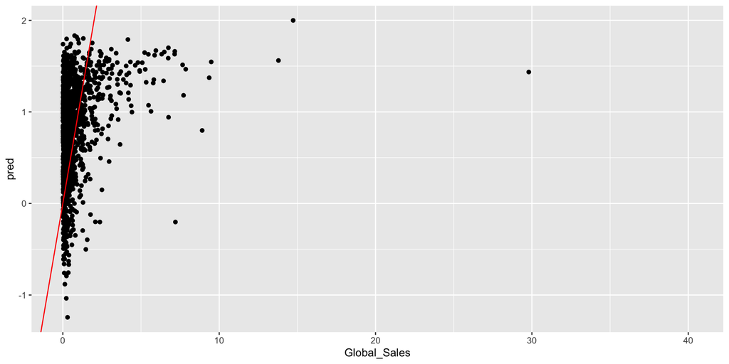

```r
rest_rows <- as.vector(createDataPartition(VGSales$Global_Sales, p = 0.8, list = FALSE))
test <- VGSales[-rest_rows, ]
rest <- VGSales[rest_rows, ]

train_rows <- as.vector(createDataPartition(rest$Global_Sales, p = 0.75, list = FALSE))

train <- rest[train_rows, ]
validate <- rest[-train_rows, ]
VGmodel <- lm(Global_Sales ~ Critic_Score + User_Score, data = train)

predictions <- add_predictions(validate, VGmodel)

ggplot(data = predictions, mapping = aes(x = Global_Sales, y = pred)) +
  geom_point() +
  geom_abline(intercept = 0, slope = 1, color = "red")
```

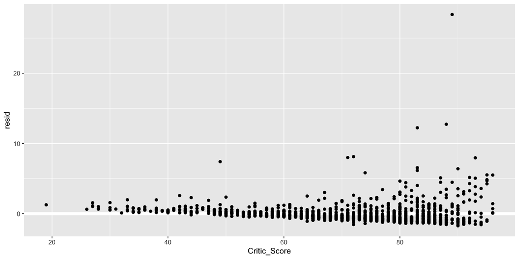

```r
resids <- add_residuals(validate, VGmodel)


ggplot(data = resids, mapping = aes(x = Critic_Score, y = resid)) +
  geom_ref_line(h = 0) +
  geom_point()
```

```r
clean <- predictions %>%
  filter(!is.na(pred))

summary(VGmodel)
```

```
##
## Call:
## lm(formula = Global_Sales ~ Critic_Score + User_Score, data = train)
##
## Residuals:
##    Min     1Q Median     3Q    Max
## -1.986 -0.709 -0.332  0.167 81.587
##
## Coefficients:
##               Estimate Std. Error t value Pr(>|t|)
## (Intercept)  -1.331438   0.189008  -7.044 2.17e-12 ***
## Critic_Score  0.042443   0.002911  14.580  < 2e-16 ***
## User_Score   -0.118879   0.028011  -4.244 2.24e-05 ***
## ---
## Signif. codes:  0 '***' 0.001 '**' 0.01 '*' 0.05 '.' 0.1 ' ' 1
##
## Residual standard error: 2.125 on 4192 degrees of freedom
##   (5840 observations deleted due to missingness)
## Multiple R-squared:  0.05399,    Adjusted R-squared:  0.05354
## F-statistic: 119.6 on 2 and 4192 DF,  p-value: < 2.2e-16
```

```r
R2(clean$pred, clean$Global_Sales)
```

```
## [1] 0.08402511
```

```r
MAE(clean$pred, clean$Global_Sales)
```

```
## [1] 0.755774
```

```r
RMSE(clean$pred, clean$Global_Sales)
```

```
## [1] 1.405702
```

```r
predictions <- add_predictions(test, VGmodel)
predictions
```

```
## # A tibble: 3,341 x 17
##    Name  Platform Year_of_Release Genre Publisher NA_Sales EU_Sales JP_Sales
##    <chr> <chr>              <dbl> <chr> <chr>        <dbl>    <dbl>    <dbl>
##  1 Mari… Wii                 2008 Raci… Nintendo     15.7     12.8      3.79
##  2 Duck… NES                 1984 Shoo… Nintendo     26.9      0.63     0.28
##  3 Nint… DS                  2005 Simu… Nintendo      9.05    11.0      1.93
##  4 Gran… PS2                 2004 Acti… Take-Two…     9.43     0.4      0.41
##  5 Anim… DS                  2005 Simu… Nintendo      2.5      3.45     5.33
##  6 Supe… Wii                 2007 Plat… Nintendo      6.06     3.35     1.2
##  7 Call… PS3                 2009 Shoo… Activisi…     4.99     3.64     0.38
##  8 Poke… GBA                 2004 Role… Nintendo      4.34     2.65     3.15
##  9 Supe… DS                  2004 Plat… Nintendo      5.01     3.07     1.25
## 10 New … 3DS                 2012 Plat… Nintendo      3.66     3.14     2.47
## # … with 3,331 more rows, and 9 more variables: Other_Sales <dbl>,
## #   Global_Sales <dbl>, Critic_Score <dbl>, Critic_Count <dbl>,
## #   User_Score <dbl>, User_Count <dbl>, Developer <chr>, Rating <chr>,
## #   pred <dbl>
```

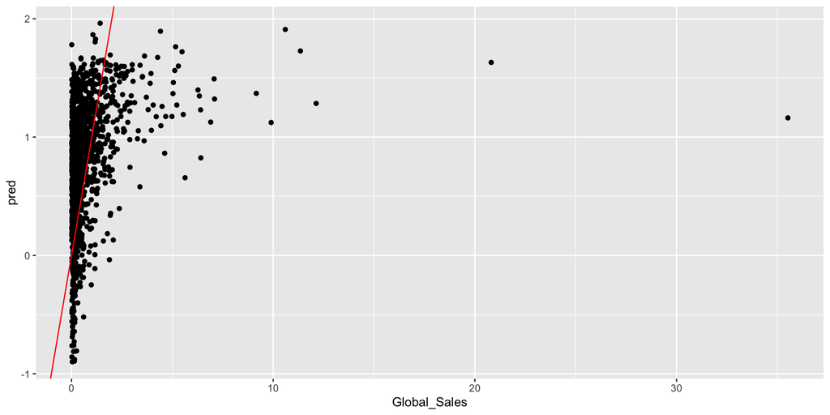

```r
ggplot(data = predictions, mapping = aes(x = Global_Sales, y = pred)) +
  geom_point() +
  geom_abline(intercept = 0, slope = 1, color = "red")
```

```r
clean <- predictions %>%
  filter(!is.na(pred))

R2(clean$pred, clean$Global_Sales)
```

```
## [1] 0.07540658
```

```r
MAE(clean$pred, clean$Global_Sales)
```

```
## [1] 0.7113552
```

```r
RMSE(clean$pred, clean$Global_Sales)
```

```
## [1] 1.48987
```

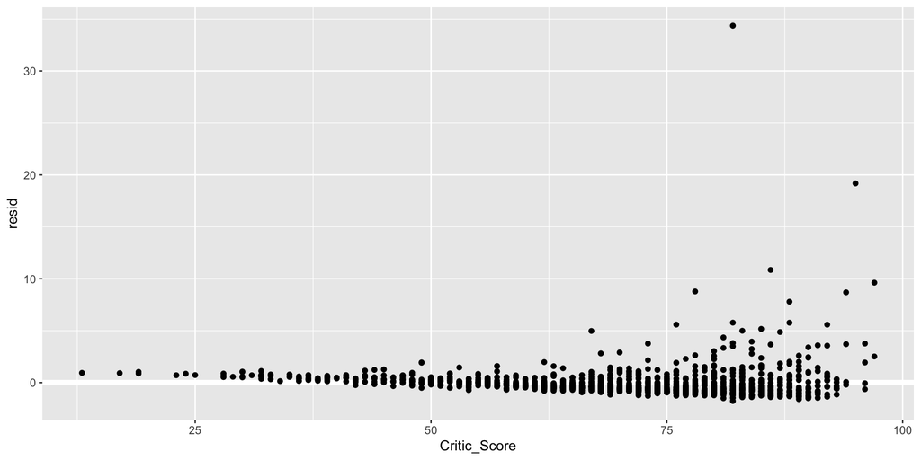

```r
resids <- add_residuals(test, VGmodel)

ggplot(data = resids, mapping = aes(x = Critic_Score, y = resid)) +
  geom_ref_line(h = 0) +
  geom_point()
```

With this last model, I wanted to test my hypothesis from the first model where the reasons for the decreases in accuracy from deliverable 2 were because of the new form of validation rather than the introduction of `playtime`. As you can see, now that the model has proper validation it accuracy actually improves given that the new mean average error is about 0.71 and the mean average value in the model within deliverable 2 was 0.74. Also the tendency for the model to under value games has continued with the inclusion of proper validation, given the trends in the residuals plot. This helps lead to the conclusion that separating the data set by high and low sales was a positive improvement.